# Time Series Analysis final Project - Competitive

MATH 1318 Time Series Analysis Final Project

Team Members: 1.Rahul k. gupta (s3635232) 2.Terrie christensen (s3664899) 3.Napapach Dechawatthanaphokin (s3613572)

14 May 2018

[figure not shown]

# Introduction

Bitcoin is a type of cryptocurrency, i.e. it is a digital currency which uses encryption techniques to generate units of the currency and verify the transfer of funds. Bitcoin is a decentralised currency, which operates independently of a central bank. An estimated 2.9 to 5.8 million unique users have a *cryptocurrency wallet*, of which most use bitcoin. The price of bitcoin has gone through various cycles of appreciation and depreciation, known as bubbles and bursts, with price fluctuations up to a magnitude of a few thousand USD in the space of a day, so that the currency has become renown for its volatility. The bitcoin historical price data gathered from the CoinMarketCap. This time series will be modelled using regression, ARIMA and GARCH methods. The report details;

- Description of the time series
- Model specification
- Model fitting and selection
- Diagnostic checking
- Predict the value of bitcoin for the following 10 days

# Initial Diagnosis

```r
# Import Libraries
library(TSA)
library(fUnitRoots)
library(forecast)
library(CombMSC)
library(lmtest)
library(fGarch)
library(rugarch)
library(zoo)
library(ggplot2)
require(readr)
require(FitAR)

Bitcoin <- read.csv("../data/Bitcoin_Historical_Price.csv", header=TRUE)
Bitcoin$Date = as.Date(Bitcoin$Date,'%Y-%m-%d')
Bitcoin.zoo <- zoo(Bitcoin$Close, Bitcoin$Date)
Bitcoin.raw = Bitcoin.zoo
```

Data is converted to time series object using zoo library. Figure shows the daily closing price of bitcoin from the 27th Apr 2013 to the 3rd Mar 2018, given in USD.

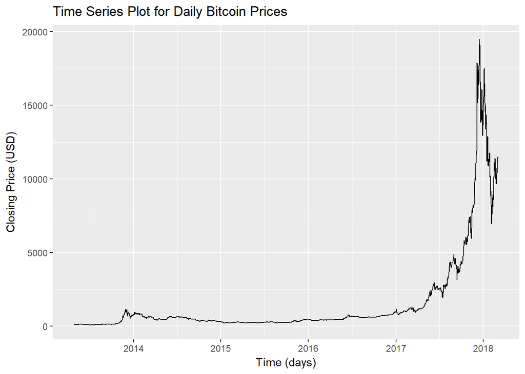

Time Series of Daily Bitcoin Prices

```r
autoplot.zoo(Bitcoin.zoo) +
  ylab('Closing Price (USD)') +
  xlab('Time (days)') +
  ggtitle("Time Series Plot for Daily Bitcoin Prices")
```

Figure shows time series of last one year

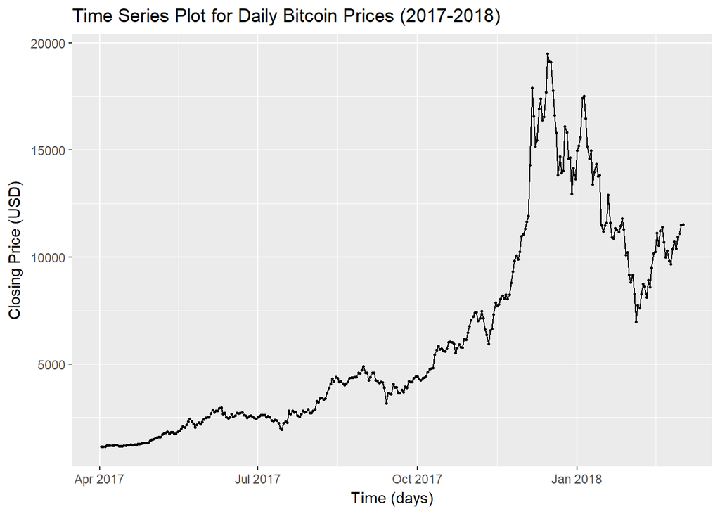

Subset Time Series of Daily Bitcoin Prices

```r
Bitcoin.2017 = Bitcoin[Bitcoin$Date > as.Date("2017-04-01"),]
Bitcoin.2017.zoo = zoo(Bitcoin.2017$Close, Bitcoin.2017$Date)
autoplot(Bitcoin.2017.zoo) +
  geom_point(size=.5) +
  ylab('Closing Price (USD)') +
  xlab('Time (days)') +
  ggtitle("Time Series Plot for Daily Bitcoin Prices (2017-2018)")
```

## Scatter Plot and correlation

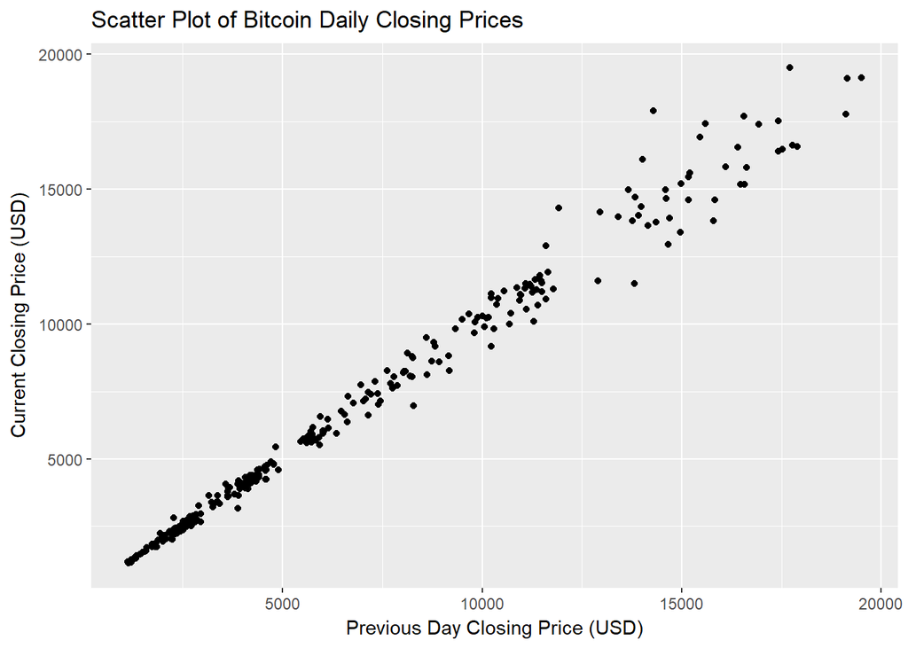

```r
ggplot(Bitcoin.2017,aes(zlag(Close), Close)) + geom_point() +
  ylab('Current Closing Price (USD)') +
  xlab('Previous Day Closing Price (USD)') +
  ggtitle("Scatter Plot of Bitcoin Daily Closing Prices")
```

```r
y = as.vector(Bitcoin.2017.zoo)
x = zlag(Bitcoin.2017.zoo)
index = 2:length(x)
cor(y[index],x[index])
```

```
## [1] 0.9935557
```

## Linear Model

```r
model.ln = lm(Bitcoin.2017.zoo~time(Bitcoin.2017.zoo)) # label the linear trend model as model.ln
summary(model.ln)
```

```
##
## Call:
## lm(formula = Bitcoin.2017.zoo ~ time(Bitcoin.2017.zoo))
##
## Residuals:
##     Min      1Q  Median      3Q     Max
## -4954.5 -1579.6  -668.9   881.2  9660.6
##
## Coefficients:
##                          Estimate Std. Error t value Pr(>|t|)
## (Intercept)            -7.021e+05  2.461e+04  -28.53   <2e-16 ***
## time(Bitcoin.2017.zoo)  4.065e+01  1.412e+00   28.79   <2e-16 ***
## ---
## Signif. codes:  0 '***' 0.001 '**' 0.01 '*' 0.05 '.' 0.1 ' ' 1
##
## Residual standard error: 2511 on 334 degrees of freedom
## Multiple R-squared:  0.7127, Adjusted R-squared:  0.7119
## F-statistic: 828.6 on 1 and 334 DF,  p-value: < 2.2e-16
```

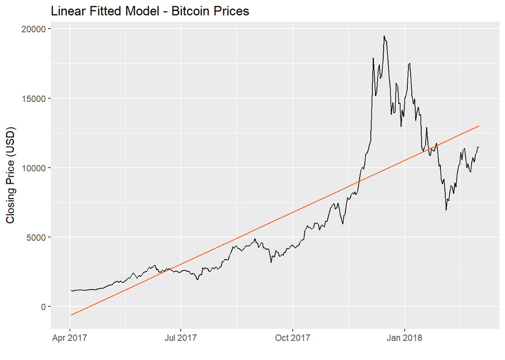

```r
ggplot(Bitcoin.2017,aes(Date,Close))+
  geom_line()  +
  ylab('Closing Price (USD)') +
  xlab('') +
  ggtitle('Linear Fitted Model - Bitcoin Prices') +
  geom_line(aes(y=fitted(model.ln)),color='#fc5e13')
```

## Residual Analysis - Linear Model

Below are the findings of residuals from linear model

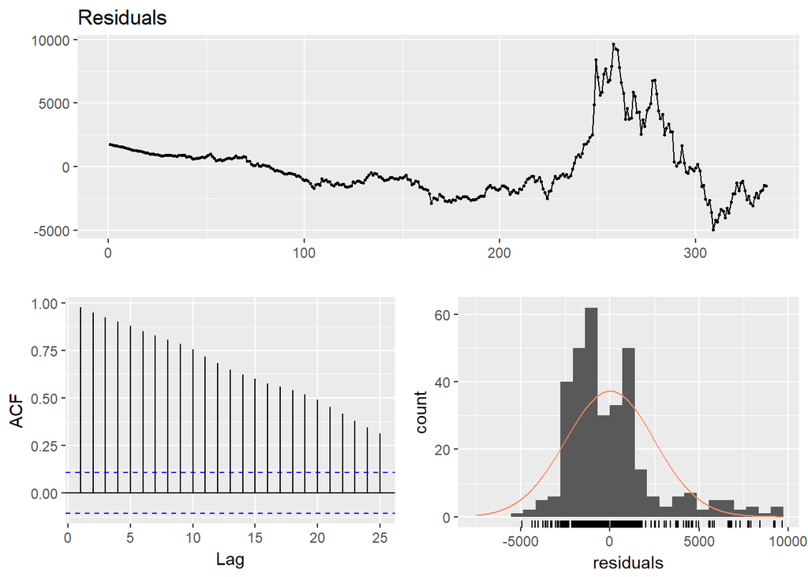

Residual Analysis Linear fitted Model

```
##
##  Breusch-Godfrey test for serial correlation of order up to 10
##
## data:  Residuals
## LM test = 321.71, df = 10, p-value < 2.2e-16
```

```r
residual_analysis_qq <- function(myresiduals, title = 'QQ Plot of Residuals') {
data=as.data.frame(qqnorm( myresiduals , plot=F))
ggplot(data,aes(x,y)) +
  geom_point() +
  geom_smooth(method="lm", se=FALSE, color='#e36209', size=.4)+
  xlab('Theoretical') +
  ylab('Sample') +
  ggtitle(title)
}

checkresiduals(model.ln)
```

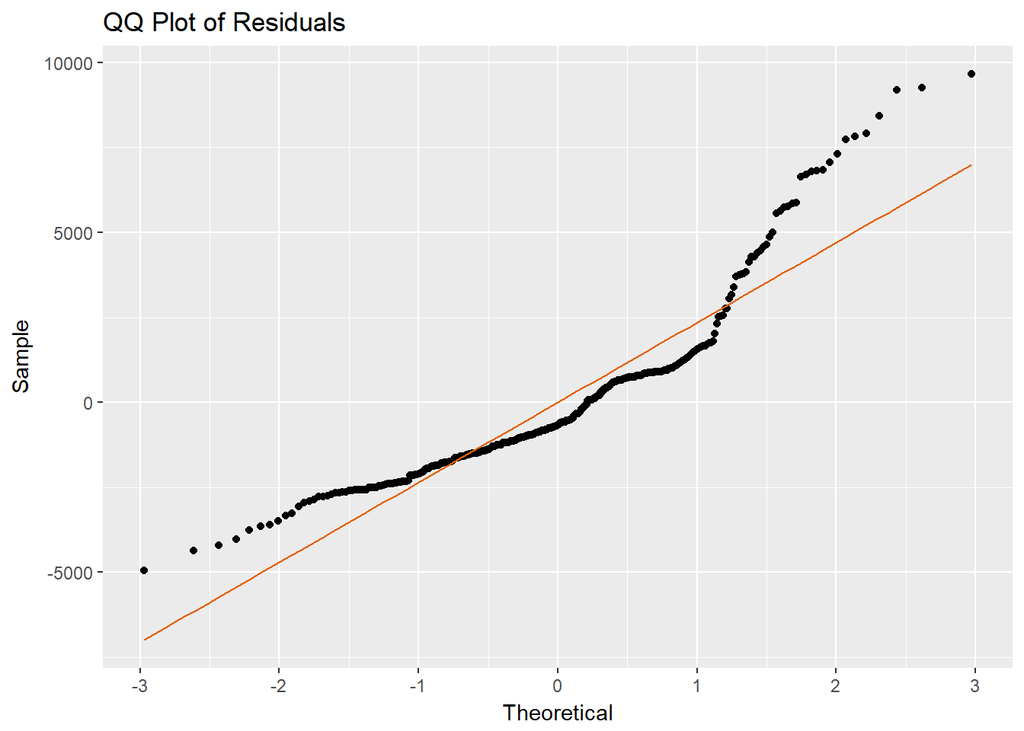

Residual Analysis Linear fitted Model

```r
residual_analysis_qq(residuals(model.ln))
```

```r
shapiro.test(as.vector(residuals(model.ln)))
```

```
##
##  Shapiro-Wilk normality test
##
## data:  as.vector(residuals(model.ln))
## W = 0.87841, p-value = 1.204e-15
```

## Quadratic Model

```r
t = as.vector(time(Bitcoin.2017.zoo))
t2 = t^2
model.qa = lm(Bitcoin.2017.zoo~ t + t2) # label the quadratic trend model as model.qa
summary(model.qa)
```

```
##
## Call:
## lm(formula = Bitcoin.2017.zoo ~ t + t2)
##
## Residuals:
##     Min      1Q  Median      3Q     Max
## -5490.1 -1286.7  -408.4   497.0  9733.1
##
## Coefficients:
##               Estimate Std. Error t value Pr(>|t|)
## (Intercept)  1.504e+07  4.874e+06   3.085  0.00221 **
## t           -1.766e+03  5.594e+02  -3.156  0.00174 **
## t2           5.183e-02  1.605e-02   3.229  0.00137 **
## ---
## Signif. codes:  0 '***' 0.001 '**' 0.01 '*' 0.05 '.' 0.1 ' ' 1
##
## Residual standard error: 2476 on 333 degrees of freedom
## Multiple R-squared:  0.7214, Adjusted R-squared:  0.7198
## F-statistic: 431.2 on 2 and 333 DF,  p-value: < 2.2e-16
```

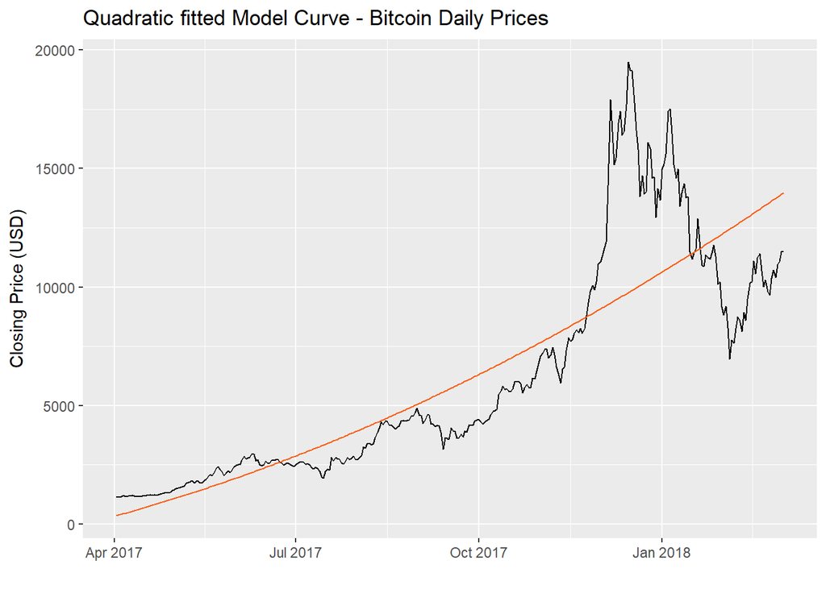

```r
ggplot(Bitcoin.2017,aes(Date,Close))+
  geom_line()  +
  ylab('Closing Price (USD)') +
  xlab('') +
  ggtitle('Quadratic fitted Model Curve - Bitcoin Daily Prices') +
  geom_line(aes(y=fitted(model.qa)),color='#fc5e13')
```

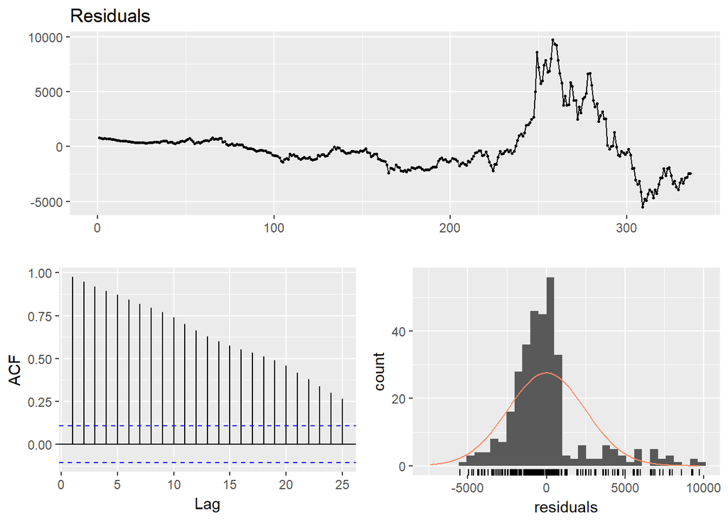

Residual Analysis Quadratic fitted Model

```
##
##  Breusch-Godfrey test for serial correlation of order up to 10
##
## data:  Residuals
## LM test = 321.7, df = 10, p-value < 2.2e-16
```

```r
checkresiduals(model.qa)
```

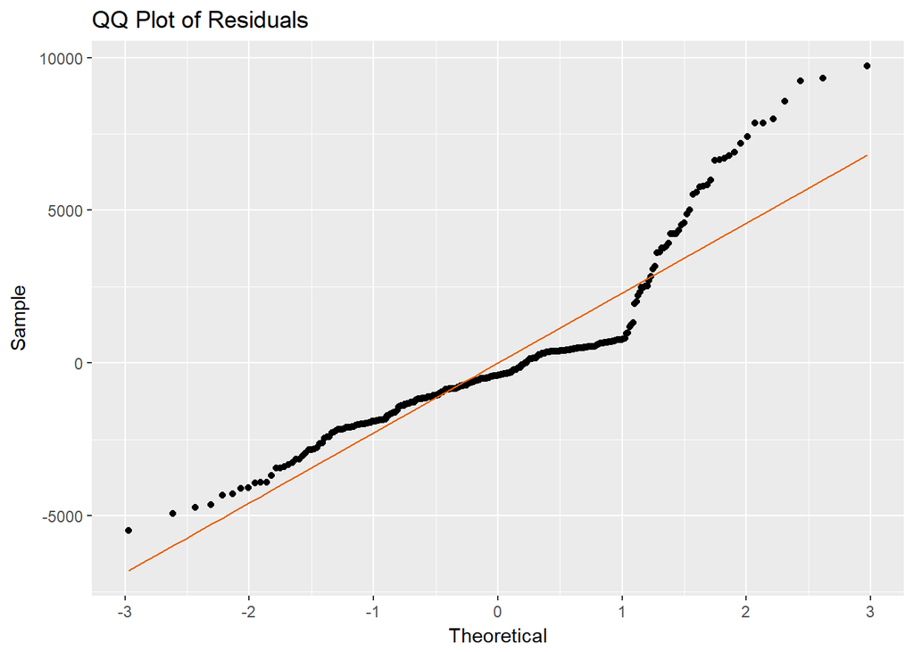

```r
residual_analysis_qq(residuals(model.qa))
```

```r
shapiro.test(as.vector(residuals(model.qa)))
```

```
##
##  Shapiro-Wilk normality test
##
## data:  as.vector(residuals(model.qa))
## W = 0.86085, p-value < 2.2e-16
```

# Models for Nonstationary Time Series

Auto regressive behaviour and non staionay Staionay is the first thing we need to check.

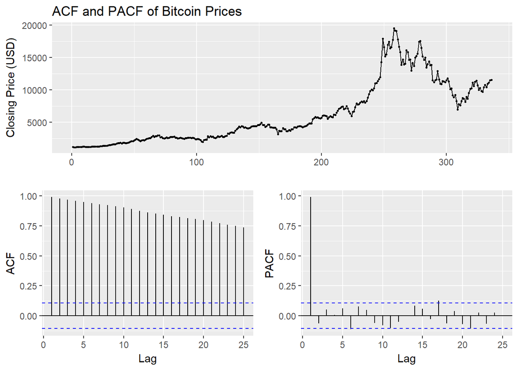

```r
ggtsdisplay(Bitcoin.2017.zoo,
            main = 'ACF and PACF of Bitcoin Prices',
            ylab='Closing Price (USD)')
```

stategy to make stationay is transfromation.

```r
Bitcoin.transform = BoxCox.ar(Bitcoin.2017.zoo, method = 'yule-walker')
```

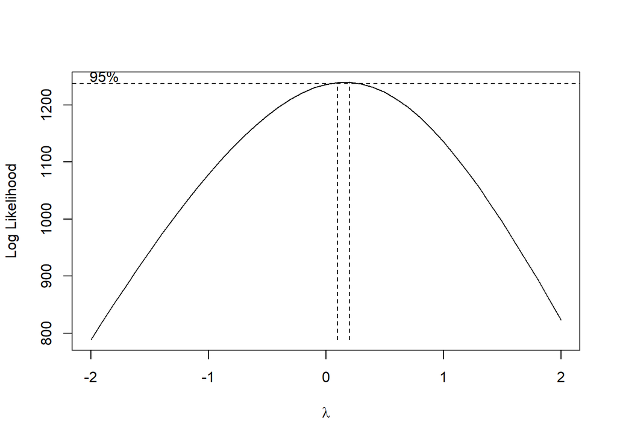

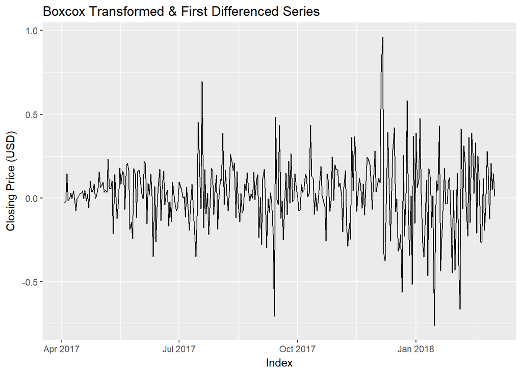

```r
lambda = sum(Bitcoin.transform$ci)/length(Bitcoin.transform$ci)
Bitcoin.boxcox = (Bitcoin.2017.zoo^lambda - 1) / lambda
Bitcoin.diff = base::diff(Bitcoin.boxcox, differences = 1)
autoplot(Bitcoin.diff) +
  ylab('Closing Price (USD)') +
  ggtitle('Boxcox Transformed & First Differenced Series')
```

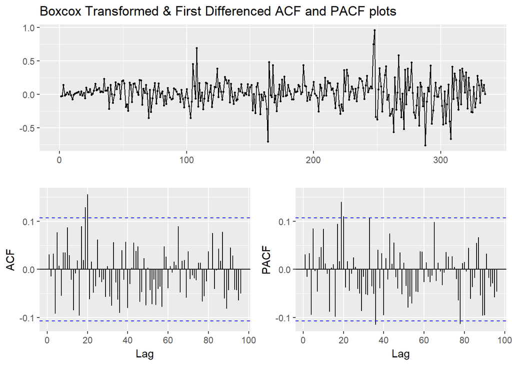

```r
ggtsdisplay(Bitcoin.diff, lag.max = 96,ci.type='ma',
            main = 'Boxcox Transformed & First Differenced ACF and PACF plots',
            ylab='')
```

```r
adf.test(Bitcoin.diff)
```

```
##
##  Augmented Dickey-Fuller Test
##
## data:  Bitcoin.diff
## Dickey-Fuller = -6.968, Lag order = 6, p-value = 0.01
## alternative hypothesis: stationary
```

```r
eacf(Bitcoin.diff)
```

```
## AR/MA
##   0 1 2 3 4 5 6 7 8 9 10 11 12 13
## 0 o o o o o o o o o o o  o  o  o
## 1 x o o o o o o o o o o  o  o  o
## 2 x o o o o o o o o o o  o  o  o
## 3 x o x o o o o o o o o  o  o  o
## 4 x x x o o o o o o o o  o  o  o
## 5 o x o x o o o o o o o  o  o  o
## 6 o x o o o o o o o o o  o  o  o
## 7 x x x o x x o o o o o  o  o  o
```

```r
# ARIMA(0,1,0),ARIMA(1,1,1),ARIMA(2,1,2),ARIMA(4,1,3)
```

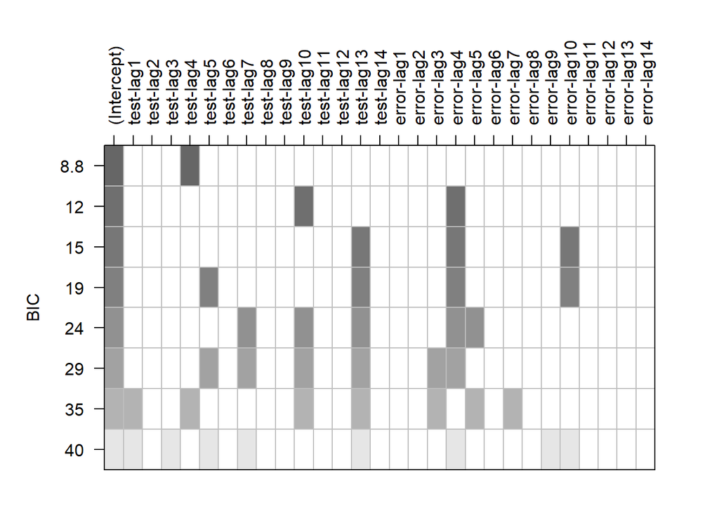

```r
res1 = armasubsets(y=Bitcoin.diff,nar=14,nma=14,y.name='test',ar.method='mle')
plot(res1)
```

```r
#ARIMA(4,1,4),ARIMA(5,1,4)
```

```r
#The final set of possible models is
# ARIMA(0,1,0),ARIMA(1,1,1),ARIMA(2,1,2),ARIMA(4,1,3)
# ARIMA(4,1,4),ARIMA(5,1,4)

# ARIMA(1,1,1)
model_111_css = arima(Bitcoin.boxcox, order=c(1,1,1),method='CSS')
coeftest(model_111_css)
```

```
##
## z test of coefficients:
##
##     Estimate Std. Error z value Pr(>|z|)
## ar1 0.021830         NA      NA       NA
## ma1 0.022332         NA      NA       NA
```

```r
model_111_ml = arima(Bitcoin.boxcox, order=c(1,1,1),method='ML')
coeftest(model_111_ml)
```

```
##
## z test of coefficients:
##
##     Estimate Std. Error z value Pr(>|z|)
## ar1 0.020106         NA      NA       NA
## ma1 0.024617         NA      NA       NA
```

```r
# ARIMA(1,1,2)
model_112_css = arima(Bitcoin.boxcox,order=c(1,1,2),method='CSS')
coeftest(model_112_css)
```

```
##
## z test of coefficients:
##
##      Estimate Std. Error z value Pr(>|z|)
## ar1 -0.698636   0.258350 -2.7042 0.006846 **
## ma1  0.749424   0.260011  2.8823 0.003948 **
## ma2 -0.012098   0.059763 -0.2024 0.839579
## ---
## Signif. codes:  0 '***' 0.001 '**' 0.01 '*' 0.05 '.' 0.1 ' ' 1
```

```r
model_112_ml = arima(Bitcoin.boxcox,order=c(1,1,2),method='ML')
coeftest(model_112_ml)
```

```
##
## z test of coefficients:
##
##      Estimate Std. Error z value Pr(>|z|)
## ar1 -0.713575   0.268293 -2.6597 0.007821 **
## ma1  0.764360   0.269563  2.8356 0.004575 **
## ma2 -0.010088   0.061085 -0.1651 0.868831
## ---
## Signif. codes:  0 '***' 0.001 '**' 0.01 '*' 0.05 '.' 0.1 ' ' 1
```

```r
# ARIMA(2,1,1)
model_211_css = arima(Bitcoin.boxcox,order=c(2,1,1),method='CSS')
coeftest(model_211_css)
```

```
##
## z test of coefficients:
##
##      Estimate Std. Error z value  Pr(>|z|)
## ar1 -0.729981   0.236531 -3.0862 0.0020274 **
## ar2 -0.010729   0.062640 -0.1713 0.8640056
## ma1  0.779953   0.230417  3.3850 0.0007119 ***
## ---
## Signif. codes:  0 '***' 0.001 '**' 0.01 '*' 0.05 '.' 0.1 ' ' 1
```

```r
model_211_ml = arima(Bitcoin.boxcox,order=c(2,1,1),method='ML')
coeftest(model_211_ml)
```

```
##
## z test of coefficients:
##
##       Estimate Std. Error z value Pr(>|z|)
## ar1  0.0091928         NA      NA       NA
## ar2 -0.0035792  0.0541984  -0.066   0.9473
## ma1  0.0335949         NA      NA       NA
```

```r
# ARIMA(2,1,2)
model_212_css = arima(Bitcoin.boxcox,order=c(2,1,2),method='CSS')
coeftest(model_212_css)
```

```
##
## z test of coefficients:
##
##      Estimate Std. Error  z value Pr(>|z|)
## ar1 -0.028545   0.079418  -0.3594   0.7193
## ar2  0.906965   0.075874  11.9535   <2e-16 ***
## ma1  0.085822   0.084577   1.0147   0.3102
## ma2 -0.913644   0.083827 -10.8991   <2e-16 ***
## ---
## Signif. codes:  0 '***' 0.001 '**' 0.01 '*' 0.05 '.' 0.1 ' ' 1
```

```r
model_212_ml = arima(Bitcoin.boxcox,order=c(2,1,2),method='ML')
coeftest(model_212_ml)
```

```
##
## z test of coefficients:
##
##       Estimate Std. Error  z value Pr(>|z|)
## ar1  0.0051321  0.0690326   0.0743   0.9407
## ar2  0.9315260  0.0654587  14.2307   <2e-16 ***
## ma1  0.0502674  0.0857493   0.5862   0.5577
## ma2 -0.9495800  0.0856749 -11.0835   <2e-16 ***
## ---
## Signif. codes:  0 '***' 0.001 '**' 0.01 '*' 0.05 '.' 0.1 ' ' 1
```

```r
# ARIMA(3,1,2)
model_312_css = arima(Bitcoin.boxcox,order=c(3,1,2),method='CSS')
coeftest(model_312_css)
```

```
##
## z test of coefficients:
##
##     Estimate Std. Error z value Pr(>|z|)
## ar1 -0.96048    0.32229 -2.9802 0.002881 **
## ar2 -0.39084    0.21351 -1.8305 0.067170 .
## ar3  0.10504    0.06089  1.7250 0.084524 .
## ma1  1.01485    0.32371  3.1351 0.001718 **
## ma2  0.45021    0.21280  2.1157 0.034370 *
## ---
## Signif. codes:  0 '***' 0.001 '**' 0.01 '*' 0.05 '.' 0.1 ' ' 1
```

```r
model_312_ml = arima(Bitcoin.boxcox,order=c(3,1,2),method='ML')
coeftest(model_312_ml)
```

```
##
## z test of coefficients:
##
##      Estimate Std. Error  z value  Pr(>|z|)
## ar1 -1.612866   0.084119 -19.1737 < 2.2e-16 ***
## ar2 -0.854203   0.108453  -7.8762 3.374e-15 ***
## ar3  0.048060   0.058338   0.8238      0.41
## ma1  1.679184   0.064867  25.8866 < 2.2e-16 ***
## ma2  0.925916   0.065388  14.1603 < 2.2e-16 ***
## ---
## Signif. codes:  0 '***' 0.001 '**' 0.01 '*' 0.05 '.' 0.1 ' ' 1
```

```r
# ARIMA(4,1,2)
model_412_css = arima(Bitcoin.boxcox,order=c(4,1,2),method='CSS')
coeftest(model_412_css)
```

```
##
## z test of coefficients:
##
##      Estimate Std. Error z value Pr(>|z|)
## ar1 -0.737242   0.415004 -1.7765  0.07566 .
## ar2 -0.499844   0.577987 -0.8648  0.38715
## ar3  0.056956   0.071481  0.7968  0.42556
## ar4 -0.080260   0.070306 -1.1416  0.25363
## ma1  0.793473   0.414413  1.9147  0.05553 .
## ma2  0.540068   0.603325  0.8952  0.37070
## ---
## Signif. codes:  0 '***' 0.001 '**' 0.01 '*' 0.05 '.' 0.1 ' ' 1
```

```r
model_412_ml = arima(Bitcoin.boxcox,order=c(4,1,2),method='ML')
coeftest(model_412_ml)
```

```
##
## z test of coefficients:
##
##      Estimate Std. Error  z value Pr(>|z|)
## ar1 -1.109588   0.055297 -20.0661   <2e-16 ***
## ar2 -0.902688   0.082158 -10.9872   <2e-16 ***
## ar3  0.059431   0.082539   0.7200   0.4715
## ar4 -0.029706   0.055097  -0.5392   0.5898
## ma1  1.185968   0.015665  75.7078   <2e-16 ***
## ma2  0.997414   0.023943  41.6570   <2e-16 ***
## ---
## Signif. codes:  0 '***' 0.001 '**' 0.01 '*' 0.05 '.' 0.1 ' ' 1
```

```r
# ARIMA(4,1,4)
model_414_css = arima(Bitcoin.boxcox,order=c(4,1,4),method='CSS')
coeftest(model_414_css)
```

```
##
## z test of coefficients:
##
##      Estimate Std. Error  z value  Pr(>|z|)
## ar1 -0.523664         NA       NA        NA
## ar2  0.162762   0.041831   3.8910 9.985e-05 ***
## ar3  0.917653   0.074325  12.3465 < 2.2e-16 ***
## ar4  0.415562         NA       NA        NA
## ma1  0.552550         NA       NA        NA
## ma2 -0.181660   0.040086  -4.5317 5.850e-06 ***
## ma3 -0.928353   0.071005 -13.0744 < 2.2e-16 ***
## ma4 -0.532390         NA       NA        NA
## ---
## Signif. codes:  0 '***' 0.001 '**' 0.01 '*' 0.05 '.' 0.1 ' ' 1
```

```r
model_414_ml = arima(Bitcoin.boxcox,order=c(4,1,4),method='ML')
coeftest(model_414_ml)
```

```
##
## z test of coefficients:
##
##      Estimate Std. Error  z value  Pr(>|z|)
## ar1 -0.857298   0.256941  -3.3366 0.0008482 ***
## ar2  0.075458   0.057469   1.3130 0.1891720
## ar3  1.120648   0.060162  18.6273 < 2.2e-16 ***
## ar4  0.637578   0.254442   2.5058 0.0122178 *
## ma1  0.922555   0.230314   4.0056 6.185e-05 ***
## ma2 -0.031454   0.060127  -0.5231 0.6008852
## ma3 -1.116176   0.056809 -19.6479 < 2.2e-16 ***
## ma4 -0.717939   0.228129  -3.1471 0.0016492 **
## ---
## Signif. codes:  0 '***' 0.001 '**' 0.01 '*' 0.05 '.' 0.1 ' ' 1
```

```r
# ARIMA(5,1,4)
model_514_css = arima(Bitcoin.boxcox,order=c(5,1,4),method='CSS')
coeftest(model_514_css)
```

```
##
## z test of coefficients:
##
##       Estimate Std. Error  z value  Pr(>|z|)
## ar1  0.0994981  0.0424432   2.3443 0.0190647 *
## ar2  0.1381344  0.0384323   3.5942 0.0003254 ***
## ar3  0.5069664  0.0030855 164.3061 < 2.2e-16 ***
## ar4  0.1650015  0.0261166   6.3179 2.652e-10 ***
## ar5  0.0902766  0.0577983   1.5619 0.1183062
## ma1 -0.0794650         NA       NA        NA
## ma2 -0.1856691  0.0430209  -4.3158 1.590e-05 ***
## ma3 -0.5132720  0.0420131 -12.2169 < 2.2e-16 ***
## ma4 -0.3071109         NA       NA        NA
## ---
## Signif. codes:  0 '***' 0.001 '**' 0.01 '*' 0.05 '.' 0.1 ' ' 1
```

```r
model_514_ml = arima(Bitcoin.boxcox,order=c(5,1,4),method='ML')
coeftest(model_514_ml)
```

```
##
## z test of coefficients:
##
##      Estimate Std. Error z value Pr(>|z|)
## ar1  0.216615   0.582131  0.3721   0.7098
## ar2  0.125234   0.255391  0.4904   0.6239
## ar3  0.472675   0.520008  0.9090   0.3634
## ar4 -0.054061   0.425997 -0.1269   0.8990
## ar5  0.109269   0.078409  1.3936   0.1634
## ma1 -0.166104   0.585688 -0.2836   0.7767
## ma2 -0.144673   0.251820 -0.5745   0.5656
## ma3 -0.438177   0.523688 -0.8367   0.4028
## ma4 -0.056627   0.413964 -0.1368   0.8912
```

```r
source('sort.score.r')
sort.score(stats::AIC(model_111_ml,model_112_ml,model_211_ml,model_212_ml,model_312_ml,model_412_ml,model_414_ml,model_514_ml), score = "aic")
```

|  | df | AIC |
| --- | --- | --- |
| model_412_ml | 7 | -103.15254 |
| model_312_ml | 6 | -102.82566 |
| model_212_ml | 5 | -102.63500 |
| model_414_ml | 9 | -101.76633 |
| model_111_ml | 3 | -100.97940 |
| model_112_ml | 4 | -100.65054 |
| model_211_ml | 4 | -98.98447 |
| model_514_ml | 10 | -95.11157 |

```r
sort.score(stats::BIC(model_111_ml,model_112_ml,model_211_ml,model_212_ml,model_312_ml,model_412_ml,model_414_ml,model_514_ml), score = "bic" )
```

|  | df | BIC |
| --- | --- | --- |
| model_111_ml | 3 | -89.53701 |
| model_112_ml | 4 | -85.39402 |
| model_211_ml | 4 | -83.72795 |
| model_212_ml | 5 | -83.56435 |
| model_312_ml | 6 | -79.94088 |
| model_412_ml | 7 | -76.45362 |
| model_414_ml | 9 | -67.43915 |
| model_514_ml | 10 | -56.97026 |

```r
fit <- Arima(Bitcoin.2017.zoo, order=c(3,1,2), lambda = lambda)
summary(fit)
```

```
## Series: Bitcoin.2017.zoo
## ARIMA(3,1,2)
## Box Cox transformation: lambda= 0.15
##
## Coefficients:
##           ar1      ar2     ar3     ma1     ma2
##       -1.6127  -0.8540  0.0479  1.6791  0.9257
## s.e.   0.0843   0.1085  0.0583  0.0651  0.0654
##
## sigma^2 estimated as 0.04215:  log likelihood=57.41
## AIC=-102.83   AICc=-102.57   BIC=-79.94
##
## Training set error measures:
##                    ME     RMSE      MAE       MPE     MAPE      MASE
## Training set 28.56452 517.2228 289.9566 0.5060551 3.975302 0.9891755
##                    ACF1
## Training set 0.06609031
```

## Residual Analysis - ARIMA Model

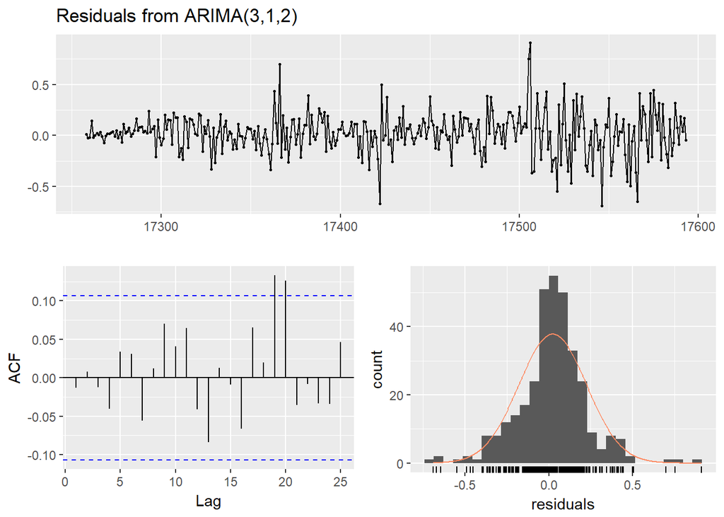

```
##
##  Ljung-Box test
##
## data:  Residuals from ARIMA(3,1,2)
## Q* = 4.8476, df = 5, p-value = 0.4348
##
## Model df: 5.   Total lags used: 10
```

```r
checkresiduals(fit)
```

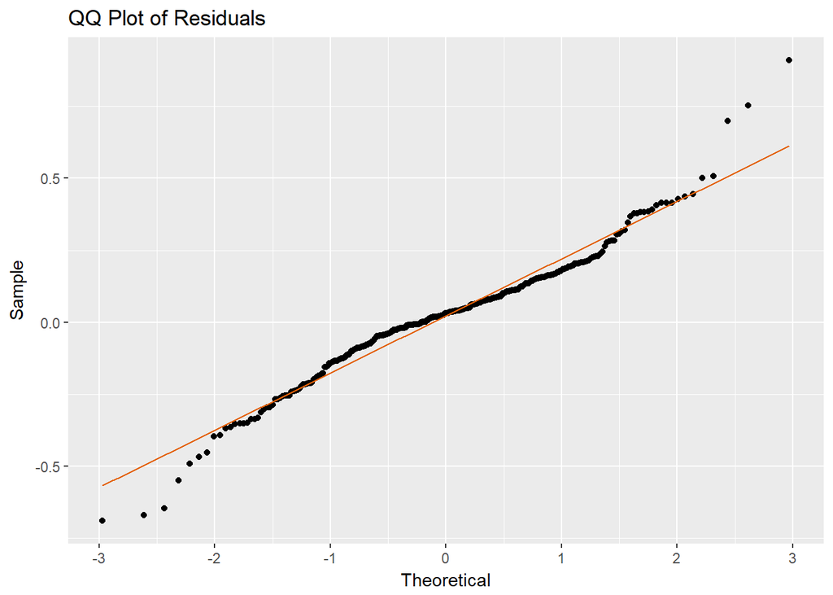

```r
residual_analysis_qq(residuals(fit))
```

```r
shapiro.test(as.vector(residuals(fit)))
```

```
##
##  Shapiro-Wilk normality test
##
## data:  as.vector(residuals(fit))
## W = 0.96352, p-value = 1.919e-07
```

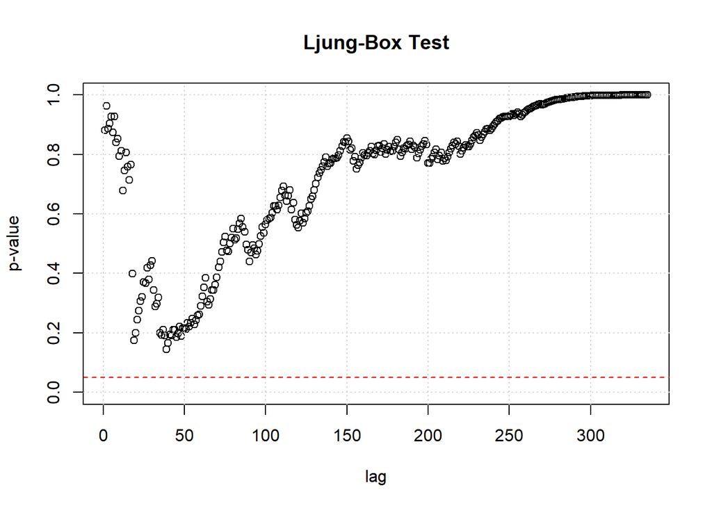

```r
x = residuals(fit)
k=0
LBQPlot(x, lag.max = length(x)-1 , StartLag = k + 1, k = 0, SquaredQ = FALSE)
grid()
```

## Forecast

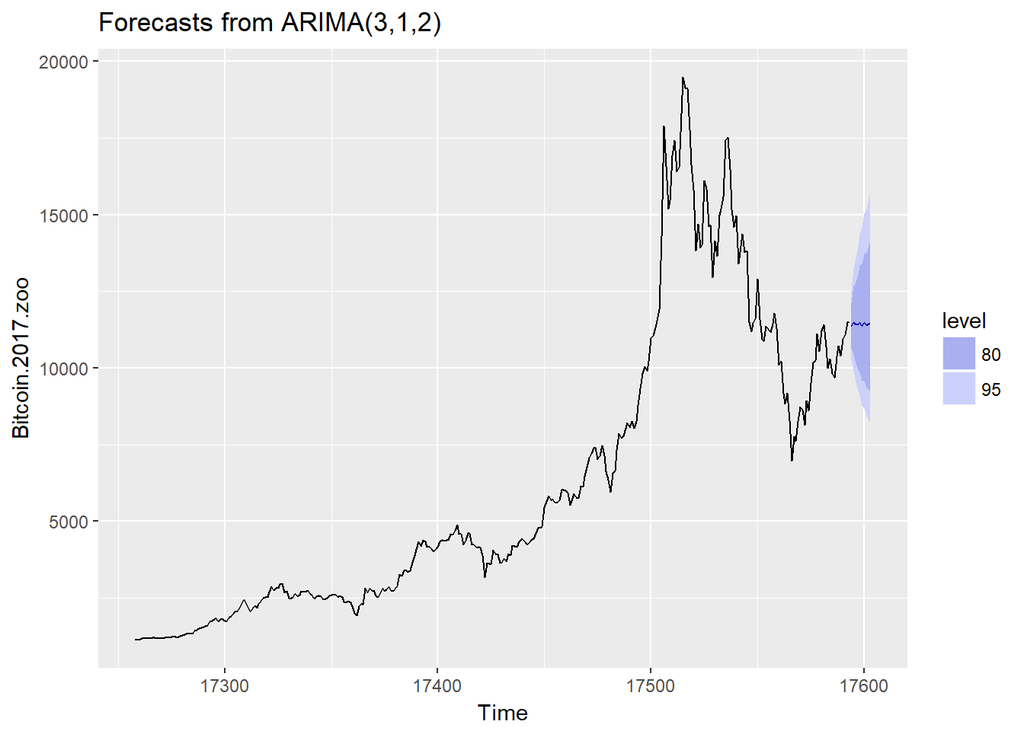

```r
autoplot(forecast(fit,h=10))
```

```r
Bitcoin.forecast <- read_csv("../data/Bitcoin_Prices_Forecasts.csv")
Bitcoin.forecast$Date = as.Date(Bitcoin.forecast$Date,'%d/%m/%y')
```

## MASE Error

```r
source('MASE.r')
MASE(Bitcoin.forecast$`Closing price`,
     as.vector(tail(fitted(forecast(fit,h=10)),10)))
```

```
## $MASE
##       MASE
## 1 3.232567
```

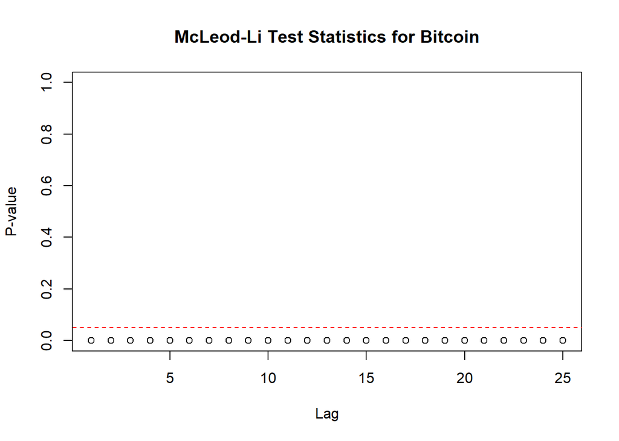

```r
McLeod.Li.test(y=Bitcoin.2017.zoo,main="McLeod-Li Test Statistics for Bitcoin")
```

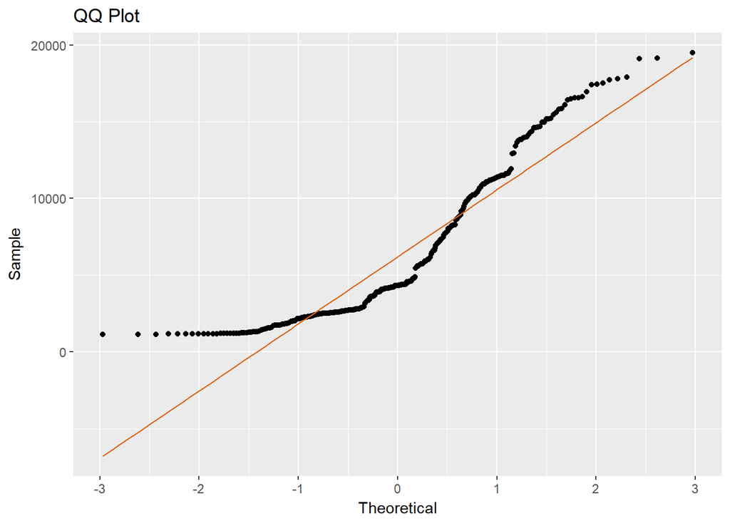

```r
residual_analysis_qq(Bitcoin.2017.zoo, 'QQ Plot')
```